# Hotel Booking Cancellation Prediction

# Introduction

In this assignment, I'll be working with hotel booking data to predict cancellations. The dataset includes details like booking information, guest demographics, and past behavior. The main goal is to clean the data, explore patterns, and build a machine learning model that predicts if a booking will be canceled.

Understanding cancellations is important for hotels since it directly affects their revenue. By identifying factors like booking lead time or guest type that influence cancellations, hotels can better manage bookings and resources.

The process will include data preprocessing (handling missing values and outliers), analyzing key trends, feature engineering to improve model accuracy, and building a predictive model. Finally, I'll assess which features are most important for predicting cancellations

**Importing relevant libraries**

```python
# Importing necessary libraries

import pandas as pd  # pandas is for handling and analyzing data.

import matplotlib.pyplot as plt  # matplotlib is for creating visualizations.

import seaborn as sb  # seaborn is for statistical data visualization.

from sklearn.preprocessing import OneHotEncoder  # Converts categorical data to binary (One-Hot Encoding).

from sklearn.preprocessing import StandardScaler  # Standardizes features by scaling them.

from sklearn.tree import DecisionTreeClassifier  # Decision tree algorithm for classification tasks.

from sklearn.model_selection import train_test_split  # Splits data into training and testing sets.

from sklearn.metrics import confusion_matrix, classification_report  # Evaluates classification models.

from sklearn import preprocessing  # Contains data preprocessing tools like scaling, encoding.

from sklearn import metrics  # For evaluating model performance.
```

```python
# Importing the data file
hotel_df = pd.read_csv('./hotel_bookings.csv')
```

**I am getting information about the `hotel_df` DataFrame, such as its structure, data types, and non-null counts. To get that, I am using the `.info()` method, which provides a concise summary of the DataFrame.**

```python
hotel_df.info()
```

```
<class 'pandas.core.frame.DataFrame'>
RangeIndex: 119390 entries, 0 to 119389
Data columns (total 32 columns):
 #   Column                          Non-Null Count   Dtype
---  ------                          --------------   -----
 0   hotel                           119390 non-null  object
 1   is_canceled                     119390 non-null  int64
 2   lead_time                       119390 non-null  int64
 3   arrival_date_year               119390 non-null  int64
 4   arrival_date_month              119390 non-null  object
 5   arrival_date_week_number        119390 non-null  int64
 6   arrival_date_day_of_month       119390 non-null  int64
 7   stays_in_weekend_nights         119390 non-null  int64
 8   stays_in_week_nights            119390 non-null  int64
 9   adults                          119390 non-null  int64
```

[output cut: 24 more lines]

**The `hotel_df.shape` attribute is used to get the dimensions of the DataFrame. It returns a tuple with two values:**

- The number of rows (first value).
- The number of columns (second value).

```python
hotel_df.shape
```

```
(119390, 32)
```

```python
# I am checking categorical values in column 'Hotel'

hotel_df.hotel
```

```
0         Resort Hotel
1         Resort Hotel
2         Resort Hotel
3         Resort Hotel
4         Resort Hotel
              ...
119385      City Hotel
119386      City Hotel
119387      City Hotel
119388      City Hotel
119389      City Hotel
Name: hotel, Length: 119390, dtype: object
```

**I am using the `.head(7)` method to display the first 7 rows of the DataFrame. This helps me quickly inspect the data and see how it is structured.**

```python
hotel_df.head(7)
```

|  | hotel | is_canceled | lead_time | arrival_date_year | arrival_date_month | arrival_date_week_number | arrival_date_day_of_month | stays_in_weekend_nights | stays_in_week_nights | adults | ... | deposit_type | agent | company | days_in_waiting_list | customer_type | adr | required_car_parking_spaces | total_of_special_requests | reservation_status | reservation_status_date |
| --- | --- | --- | --- | --- | --- | --- | --- | --- | --- | --- | --- | --- | --- | --- | --- | --- | --- | --- | --- | --- | --- |
| 0 | Resort Hotel | 0 | 342 | 2015 | July | 27 | 1 | 0 | 0 | 2 | ... | No Deposit | NaN | NaN | 0 | Transient | 0.0 | 0 | 0 | Check-Out | 2015-07-01 |
| 1 | Resort Hotel | 0 | 737 | 2015 | July | 27 | 1 | 0 | 0 | 2 | ... | No Deposit | NaN | NaN | 0 | Transient | 0.0 | 0 | 0 | Check-Out | 2015-07-01 |
| 2 | Resort Hotel | 0 | 7 | 2015 | July | 27 | 1 | 0 | 1 | 1 | ... | No Deposit | NaN | NaN | 0 | Transient | 75.0 | 0 | 0 | Check-Out | 2015-07-02 |
| 3 | Resort Hotel | 0 | 13 | 2015 | July | 27 | 1 | 0 | 1 | 1 | ... | No Deposit | 304.0 | NaN | 0 | Transient | 75.0 | 0 | 0 | Check-Out | 2015-07-02 |
| 4 | Resort Hotel | 0 | 14 | 2015 | July | 27 | 1 | 0 | 2 | 2 | ... | No Deposit | 240.0 | NaN | 0 | Transient | 98.0 | 0 | 1 | Check-Out | 2015-07-03 |
| 5 | Resort Hotel | 0 | 14 | 2015 | July | 27 | 1 | 0 | 2 | 2 | ... | No Deposit | 240.0 | NaN | 0 | Transient | 98.0 | 0 | 1 | Check-Out | 2015-07-03 |
| 6 | Resort Hotel | 0 | 0 | 2015 | July | 27 | 1 | 0 | 2 | 2 | ... | No Deposit | NaN | NaN | 0 | Transient | 107.0 | 0 | 0 | Check-Out | 2015-07-03 |

7 rows × 32 columns

****I am using the `.tail(2)` method to display the last 2 rows of the DataFrame. This allows me to see the ending portion of the data.****

```python
hotel_df.tail(2)
```

|  | hotel | is_canceled | lead_time | arrival_date_year | arrival_date_month | arrival_date_week_number | arrival_date_day_of_month | stays_in_weekend_nights | stays_in_week_nights | adults | ... | deposit_type | agent | company | days_in_waiting_list | customer_type | adr | required_car_parking_spaces | total_of_special_requests | reservation_status | reservation_status_date |
| --- | --- | --- | --- | --- | --- | --- | --- | --- | --- | --- | --- | --- | --- | --- | --- | --- | --- | --- | --- | --- | --- |
| 119388 | City Hotel | 0 | 109 | 2017 | August | 35 | 31 | 2 | 5 | 2 | ... | No Deposit | 89.0 | NaN | 0 | Transient | 104.4 | 0 | 0 | Check-Out | 2017-09-07 |
| 119389 | City Hotel | 0 | 205 | 2017 | August | 35 | 29 | 2 | 7 | 2 | ... | No Deposit | 9.0 | NaN | 0 | Transient | 151.2 | 0 | 2 | Check-Out | 2017-09-07 |

2 rows × 32 columns

****I am using the `.describe()` method to generate summary statistics of the DataFrame. This gives me key insights like the count, mean, standard deviation, and percentiles for the numerical columns.****

```python
hotel_df.describe()
```

|  | is_canceled | lead_time | arrival_date_year | arrival_date_week_number | arrival_date_day_of_month | stays_in_weekend_nights | stays_in_week_nights | adults | children | babies | is_repeated_guest | previous_cancellations | previous_bookings_not_canceled | booking_changes | agent | company | days_in_waiting_list | adr | required_car_parking_spaces | total_of_special_requests |
| --- | --- | --- | --- | --- | --- | --- | --- | --- | --- | --- | --- | --- | --- | --- | --- | --- | --- | --- | --- | --- |
| count | 119390.000000 | 119390.000000 | 119390.000000 | 119390.000000 | 119390.000000 | 119390.000000 | 119390.000000 | 119390.000000 | 119386.000000 | 119390.000000 | 119390.000000 | 119390.000000 | 119390.000000 | 119390.000000 | 103050.000000 | 6797.000000 | 119390.000000 | 119390.000000 | 119390.000000 | 119390.000000 |
| mean | 0.370416 | 104.011416 | 2016.156554 | 27.165173 | 15.798241 | 0.927599 | 2.500302 | 1.856403 | 0.103890 | 0.007949 | 0.031912 | 0.087118 | 0.137097 | 0.221124 | 86.693382 | 189.266735 | 2.321149 | 101.831122 | 0.062518 | 0.571363 |
| std | 0.482918 | 106.863097 | 0.707476 | 13.605138 | 8.780829 | 0.998613 | 1.908286 | 0.579261 | 0.398561 | 0.097436 | 0.175767 | 0.844336 | 1.497437 | 0.652306 | 110.774548 | 131.655015 | 17.594721 | 50.535790 | 0.245291 | 0.792798 |
| min | 0.000000 | 0.000000 | 2015.000000 | 1.000000 | 1.000000 | 0.000000 | 0.000000 | 0.000000 | 0.000000 | 0.000000 | 0.000000 | 0.000000 | 0.000000 | 0.000000 | 1.000000 | 6.000000 | 0.000000 | -6.380000 | 0.000000 | 0.000000 |
| 25% | 0.000000 | 18.000000 | 2016.000000 | 16.000000 | 8.000000 | 0.000000 | 1.000000 | 2.000000 | 0.000000 | 0.000000 | 0.000000 | 0.000000 | 0.000000 | 0.000000 | 9.000000 | 62.000000 | 0.000000 | 69.290000 | 0.000000 | 0.000000 |
| 50% | 0.000000 | 69.000000 | 2016.000000 | 28.000000 | 16.000000 | 1.000000 | 2.000000 | 2.000000 | 0.000000 | 0.000000 | 0.000000 | 0.000000 | 0.000000 | 0.000000 | 14.000000 | 179.000000 | 0.000000 | 94.575000 | 0.000000 | 0.000000 |
| 75% | 1.000000 | 160.000000 | 2017.000000 | 38.000000 | 23.000000 | 2.000000 | 3.000000 | 2.000000 | 0.000000 | 0.000000 | 0.000000 | 0.000000 | 0.000000 | 0.000000 | 229.000000 | 270.000000 | 0.000000 | 126.000000 | 0.000000 | 1.000000 |
| max | 1.000000 | 737.000000 | 2017.000000 | 53.000000 | 31.000000 | 19.000000 | 50.000000 | 55.000000 | 10.000000 | 10.000000 | 1.000000 | 26.000000 | 72.000000 | 21.000000 | 535.000000 | 543.000000 | 391.000000 | 5400.000000 | 8.000000 | 5.000000 |

# 1. Data Pre-processing (25%)

```python
#checking all the columns

hotel_df.columns
```

```
Index(['hotel', 'is_canceled', 'lead_time', 'arrival_date_year',
       'arrival_date_month', 'arrival_date_week_number',
       'arrival_date_day_of_month', 'stays_in_weekend_nights',
       'stays_in_week_nights', 'adults', 'children', 'babies', 'meal',
       'country', 'market_segment', 'distribution_channel',
       'is_repeated_guest', 'previous_cancellations',
       'previous_bookings_not_canceled', 'reserved_room_type',
       'assigned_room_type', 'booking_changes', 'deposit_type', 'agent',
       'company', 'days_in_waiting_list', 'customer_type', 'adr',
       'required_car_parking_spaces', 'total_of_special_requests',
       'reservation_status', 'reservation_status_date'],
      dtype='object')
```

**Drop irrelevant columns**

It will significantly reduce the time and effort you need to invest. As a general guideline, columns containing IDs, dates, or irrelevant information are typically considered redundant and offer little value for predictive analysis.

****After accessing the data, I am dropping the following columns because they are not relevant for the model:****

- ****`arrival_date_year`, `arrival_date_week_number`, `arrival_date_day_of_month`: These provide detailed date information that is not be necessary for the model because it has dates****
- ****`country`: This column is also not relevant for the model as we are not analyzing/predicting that where the customers are coming from.****
- ****`reservation_status`, `reservation_status_date`: These columns are directly tied to the outcome and might introduce data leakage.****
- ****`arrival_date_month`: Redundant after removing other date-related columns.****
- ****`previous_bookings_not_canceled`: This column is dropped because we can get this information from the column 'is_cancelled' so we can drop this.****

```python
# After accessing the data I am dropping the following columns

hotel_df.drop(columns=['arrival_date_year',
                       'arrival_date_week_number',
                       'arrival_date_day_of_month',
                       'country',
                       'reservation_status',
                       'reservation_status_date',
                       'arrival_date_month',
                       'market_segment', # this one is dropped later on because it is not that relevant I could also drop distribution_channel
                       'previous_bookings_not_canceled'
                       ], inplace=True)
hotel_df
```

|  | hotel | is_canceled | lead_time | stays_in_weekend_nights | stays_in_week_nights | adults | children | babies | meal | distribution_channel | ... | assigned_room_type | booking_changes | deposit_type | agent | company | days_in_waiting_list | customer_type | adr | required_car_parking_spaces | total_of_special_requests |
| --- | --- | --- | --- | --- | --- | --- | --- | --- | --- | --- | --- | --- | --- | --- | --- | --- | --- | --- | --- | --- | --- |
| 0 | Resort Hotel | 0 | 342 | 0 | 0 | 2 | 0.0 | 0 | BB | Direct | ... | C | 3 | No Deposit | NaN | NaN | 0 | Transient | 0.00 | 0 | 0 |
| 1 | Resort Hotel | 0 | 737 | 0 | 0 | 2 | 0.0 | 0 | BB | Direct | ... | C | 4 | No Deposit | NaN | NaN | 0 | Transient | 0.00 | 0 | 0 |
| 2 | Resort Hotel | 0 | 7 | 0 | 1 | 1 | 0.0 | 0 | BB | Direct | ... | C | 0 | No Deposit | NaN | NaN | 0 | Transient | 75.00 | 0 | 0 |
| 3 | Resort Hotel | 0 | 13 | 0 | 1 | 1 | 0.0 | 0 | BB | Corporate | ... | A | 0 | No Deposit | 304.0 | NaN | 0 | Transient | 75.00 | 0 | 0 |
| 4 | Resort Hotel | 0 | 14 | 0 | 2 | 2 | 0.0 | 0 | BB | TA/TO | ... | A | 0 | No Deposit | 240.0 | NaN | 0 | Transient | 98.00 | 0 | 1 |
| ... | ... | ... | ... | ... | ... | ... | ... | ... | ... | ... | ... | ... | ... | ... | ... | ... | ... | ... | ... | ... | ... |
| 119385 | City Hotel | 0 | 23 | 2 | 5 | 2 | 0.0 | 0 | BB | TA/TO | ... | A | 0 | No Deposit | 394.0 | NaN | 0 | Transient | 96.14 | 0 | 0 |
| 119386 | City Hotel | 0 | 102 | 2 | 5 | 3 | 0.0 | 0 | BB | TA/TO | ... | E | 0 | No Deposit | 9.0 | NaN | 0 | Transient | 225.43 | 0 | 2 |
| 119387 | City Hotel | 0 | 34 | 2 | 5 | 2 | 0.0 | 0 | BB | TA/TO | ... | D | 0 | No Deposit | 9.0 | NaN | 0 | Transient | 157.71 | 0 | 4 |
| 119388 | City Hotel | 0 | 109 | 2 | 5 | 2 | 0.0 | 0 | BB | TA/TO | ... | A | 0 | No Deposit | 89.0 | NaN | 0 | Transient | 104.40 | 0 | 0 |
| 119389 | City Hotel | 0 | 205 | 2 | 7 | 2 | 0.0 | 0 | HB | TA/TO | ... | A | 0 | No Deposit | 9.0 | NaN | 0 | Transient | 151.20 | 0 | 2 |

119390 rows × 23 columns

****I am using the `.columns` attribute to loop through and see which columns I have left in the DataFrame after dropping the irrelevant ones. This helps me confirm the current structure of the data and ensures I’m working with the necessary features for my analysis.****

```python
hotel_df.columns
```

```
Index(['hotel', 'is_canceled', 'lead_time', 'stays_in_weekend_nights',
       'stays_in_week_nights', 'adults', 'children', 'babies', 'meal',
       'distribution_channel', 'is_repeated_guest', 'previous_cancellations',
       'reserved_room_type', 'assigned_room_type', 'booking_changes',
       'deposit_type', 'agent', 'company', 'days_in_waiting_list',
       'customer_type', 'adr', 'required_car_parking_spaces',
       'total_of_special_requests'],
      dtype='object')
```

## 1.1 Missing Values (10%)

Identify and handle missing values.

****I am using the `.shape` attribute to check the dimensions of the DataFrame, giving me the number of rows and columns.****

```
hotel_df.shape  # Displays the shape of the DataFrame
```

```python
hotel_df.shape
```

```
(119390, 23)
```

****I am using `.isnull()/isna` to identify the missing values in the DataFrame and `.sum()` to add them all, This helps me see how many values are missing in each column.****

```python
# Handling missing values
hotel_df.isnull().sum()
```

```
hotel                               0
is_canceled                         0
lead_time                           0
stays_in_weekend_nights             0
stays_in_week_nights                0
adults                              0
children                            4
babies                              0
meal                                0
distribution_channel                0
is_repeated_guest                   0
previous_cancellations              0
reserved_room_type                  0
assigned_room_type                  0
booking_changes                     0
deposit_type                        0
agent                           16340
company                        112593
days_in_waiting_list                0
customer_type                       0
adr                                 0
required_car_parking_spaces         0
total_of_special_requests           0
dtype: int64
```

****I am plotting a heatmap to visualize the missing values in the DataFrame. This allows me to quickly identify which columns have missing data.****

```
plt.figure(figsize=(30, 12))  # Sets the figure size
sb.heatmap(hotel_df.isnull(), cbar=False, cmap='coolwarm', yticklabels=False)  # Creates the heatmap using seaborn library
plt.xlabel('Columns')  # Labels the x-axis
plt.title('Heatmap for all missing values')  # Sets the title of the plot
plt.show()  # Displays the plot
```

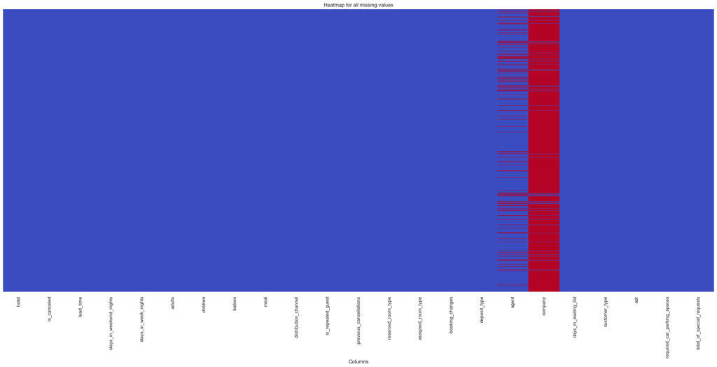

```python
# Plotting heatmap for missing values

plt.figure(figsize=(30, 12))
sb.heatmap(hotel_df.isnull(), cbar=False, cmap='coolwarm', yticklabels=False)
plt.xlabel('Columns')
plt.title('Heatmap for all missing values')
plt.show()
```

****Additionally, I noticed the following missing values that need to be addressed because column 'agent' and 'company' has huge missing values and it will not help the model at all for prediction****

- ****`agent`: `16,340` missing values****
- ****`company`: `112,593` missing values****

```python
hotel_df.drop(columns=['company',
                       'agent'
                       ], inplace=True)
hotel_df
```

|  | hotel | is_canceled | lead_time | stays_in_weekend_nights | stays_in_week_nights | adults | children | babies | meal | distribution_channel | ... | previous_cancellations | reserved_room_type | assigned_room_type | booking_changes | deposit_type | days_in_waiting_list | customer_type | adr | required_car_parking_spaces | total_of_special_requests |
| --- | --- | --- | --- | --- | --- | --- | --- | --- | --- | --- | --- | --- | --- | --- | --- | --- | --- | --- | --- | --- | --- |
| 0 | Resort Hotel | 0 | 342 | 0 | 0 | 2 | 0.0 | 0 | BB | Direct | ... | 0 | C | C | 3 | No Deposit | 0 | Transient | 0.00 | 0 | 0 |
| 1 | Resort Hotel | 0 | 737 | 0 | 0 | 2 | 0.0 | 0 | BB | Direct | ... | 0 | C | C | 4 | No Deposit | 0 | Transient | 0.00 | 0 | 0 |
| 2 | Resort Hotel | 0 | 7 | 0 | 1 | 1 | 0.0 | 0 | BB | Direct | ... | 0 | A | C | 0 | No Deposit | 0 | Transient | 75.00 | 0 | 0 |
| 3 | Resort Hotel | 0 | 13 | 0 | 1 | 1 | 0.0 | 0 | BB | Corporate | ... | 0 | A | A | 0 | No Deposit | 0 | Transient | 75.00 | 0 | 0 |
| 4 | Resort Hotel | 0 | 14 | 0 | 2 | 2 | 0.0 | 0 | BB | TA/TO | ... | 0 | A | A | 0 | No Deposit | 0 | Transient | 98.00 | 0 | 1 |
| ... | ... | ... | ... | ... | ... | ... | ... | ... | ... | ... | ... | ... | ... | ... | ... | ... | ... | ... | ... | ... | ... |
| 119385 | City Hotel | 0 | 23 | 2 | 5 | 2 | 0.0 | 0 | BB | TA/TO | ... | 0 | A | A | 0 | No Deposit | 0 | Transient | 96.14 | 0 | 0 |
| 119386 | City Hotel | 0 | 102 | 2 | 5 | 3 | 0.0 | 0 | BB | TA/TO | ... | 0 | E | E | 0 | No Deposit | 0 | Transient | 225.43 | 0 | 2 |
| 119387 | City Hotel | 0 | 34 | 2 | 5 | 2 | 0.0 | 0 | BB | TA/TO | ... | 0 | D | D | 0 | No Deposit | 0 | Transient | 157.71 | 0 | 4 |
| 119388 | City Hotel | 0 | 109 | 2 | 5 | 2 | 0.0 | 0 | BB | TA/TO | ... | 0 | A | A | 0 | No Deposit | 0 | Transient | 104.40 | 0 | 0 |
| 119389 | City Hotel | 0 | 205 | 2 | 7 | 2 | 0.0 | 0 | HB | TA/TO | ... | 0 | A | A | 0 | No Deposit | 0 | Transient | 151.20 | 0 | 2 |

119390 rows × 21 columns

```python
# Using isna or isnull function to check any null values and using and sum function to find the sum of all null

hotel_df.isna().sum()
```

```
hotel                          0
is_canceled                    0
lead_time                      0
stays_in_weekend_nights        0
stays_in_week_nights           0
adults                         0
children                       4
babies                         0
meal                           0
distribution_channel           0
is_repeated_guest              0
previous_cancellations         0
reserved_room_type             0
assigned_room_type             0
booking_changes                0
deposit_type                   0
days_in_waiting_list           0
customer_type                  0
adr                            0
required_car_parking_spaces    0
total_of_special_requests      0
dtype: int64
```

****After using the `isna()` function, I noticed that there are 4 null values in the `children` column. Therefore, I will replace these missing values using `fillna()`, rather than dropping the column I replaced the values****

```python
# After using isna or isnull function I have noticed that in children column there are 4 null values. Therefore I will replace them values using fillna()

hotel_df['children'] = hotel_df['children'].fillna(0)
hotel_df['children'].isna().sum()
hotel_df.isna().sum() # checking if there are any null values left
```

```
hotel                          0
is_canceled                    0
lead_time                      0
stays_in_weekend_nights        0
stays_in_week_nights           0
adults                         0
children                       0
babies                         0
meal                           0
distribution_channel           0
is_repeated_guest              0
previous_cancellations         0
reserved_room_type             0
assigned_room_type             0
booking_changes                0
deposit_type                   0
days_in_waiting_list           0
customer_type                  0
adr                            0
required_car_parking_spaces    0
total_of_special_requests      0
dtype: int64
```

## Unique values

Find out unique values in columns. This will help you in identifying in-consistent data.

**Simply looping through all the columns using a `for loop` to look for each columns uniques values**

```python
# finding unique values

# for column in hotel_df.columns:
#     print(f"{column}: {hotel_df[column].unique()}")

# hotel_df[['hotel','is_canceled']].value_counts()

for column in hotel_df.columns:
    print(f"{column}:")
    print(hotel_df[column].value_counts())
    print('-' * 50)  # Separator line of 50 dashes
```

```
hotel:
hotel
City Hotel      79330
Resort Hotel    40060
Name: count, dtype: int64
--------------------------------------------------
is_canceled:
is_canceled
0    75166
1    44224
Name: count, dtype: int64
--------------------------------------------------
lead_time:
lead_time
0      6345
1      3460
2      2069
3      1816
4      1715
       ...
400       1
370       1
532       1
371       1
463       1
Name: count, Length: 479, dtype: int64
--------------------------------------------------
stays_in_weekend_nights:
stays_in_weekend_nights
0     51998
2     33308
1     30626
4      1855
3      1259
6       153
5        79
8        60
7        19
9        11
10        7
```

[output cut: 230 more lines]

```
2        28
3         3
8         2
Name: count, dtype: int64
--------------------------------------------------
total_of_special_requests:
total_of_special_requests
0    70318
1    33226
2    12969
3     2497
4      340
5       40
Name: count, dtype: int64
--------------------------------------------------
```

## 1.2 Removing Inconsistent values and Outliers (10%)

Detecting inconsistencies can be achieved through a variety of methods. Some can be identified by examining unique values within each column, while others may require a solid understanding of the problem domain. Since you might not be an expert in the hotel or hospitality industry, here are some helpful hints:

Hints:

1. Check for incomplete bookings, such as reservations with zero adults, babies, or children.
2. Examine rows with zeros in both 'stays_in_weekend_nights' and 'stays_in_week_nights.'

****I am checking the indices where the total number of `adults`, `children`, and `babies` is zero. This helps me identify any rows where there are no guests listed.****

```python
# checking on what index adults,children and babies are zero

hotel_df[hotel_df['adults'] +
         hotel_df['children'] +
         hotel_df['babies'] == 0 ].index
```

```
Index([  2224,   2409,   3181,   3684,   3708,   4127,   9376,  31765,  32029,
        32827,
       ...
       112558, 113188, 114583, 114908, 114911, 115029, 115091, 116251, 116534,
       117087],
      dtype='int64', length=180)
```

```python
# Removing rows with zero adults.

hotel_df = hotel_df.drop(hotel_df[hotel_df['adults'] == 0].index)
```

```python
# testing if it is working, and the index is empty after running it.

hotel_df[hotel_df['adults'] == 0 ].index
```

```
Index([], dtype='int64')
```

**Removing Rows with Zero Stays**

In this dataset, `stays_in_week_nights` and `stays_in_weekend_nights` represent how many nights a guest stayed during the week and weekend, respectively.

I decided to drop any rows where both these columns are `0`, since it means the guest didn’t actually stay at the hotel. These entries likely reflect:

- Incomplete or invalid bookings,
- Data entry errors,
- Or bookings that were canceled before any stay happened.

Removing these rows helps clean the data and ensures that the machine learning model only uses **relevant information** based on real stays.

```python
hotel_df = hotel_df.drop(hotel_df[(hotel_df['stays_in_week_nights'] == 0) & (hotel_df['stays_in_weekend_nights'] == 0)].index)
```

```python
# Tested if the specific rows been dropped and outcome is positive there are [0] bookings with the value of zero

hotel_df[(hotel_df['stays_in_week_nights'] == 0) & (hotel_df['stays_in_weekend_nights'] == 0)].index
```

```
Index([], dtype='int64')
```

**Resetting the DataFrame Index**

I used `reset_index()` to reorganize the DataFrame after dropping rows. This ensures the index is reset, eliminating any gaps caused by the removed rows. The `drop=True` argument ensures the old index is not added as a new column, and `inplace=True` updates the DataFrame directly.

```python
# Resetting the index to get rid of empty rows

hotel_df.reset_index(drop= True , inplace=True)
```

**Lead Time Boxplot using Matplotlib**

I used `matplotlib` and `seaborn` to plot a boxplot of the `lead_time` variable to visualize its distribution and detect outliers.

```
plt.rcParams['figure.figsize'] = (15, 5)
sb.boxplot(x=hotel_df['lead_time'])
```

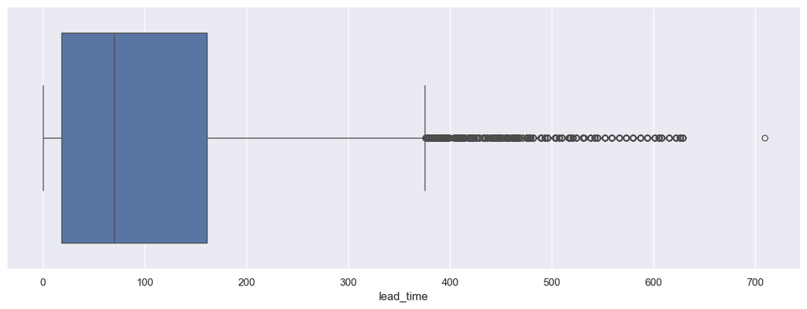

```python
# Utilizing matplotlib library to plot the graph

plt.rcParams['figure.figsize']=(15,5)
sb.boxplot(x=hotel_df['lead_time'])
```

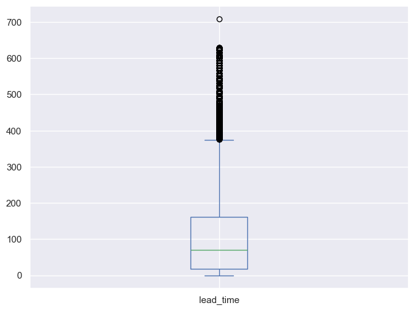

```python
# Box plotting using pandas for lead_time columns

hotel_df.plot(y=['lead_time'],kind='box',figsize=(8,6))

# Box plotting using seaborn and plt

# sns.boxplot(hotel_df['lead_time'],width=.1)
# plt.show()
```

**Finding Outliers Using the `describe()` Method**

I used the `describe()` method to get summary statistics for the `lead_time` column. This includes the count, mean, standard deviation, and key percentiles (25%, 50%, 75%). Outliers can be identified by looking for values that are far from the majority, such as those beyond the interquartile range (IQR).

```python
# finding the outliers using describe method

hotel_df['lead_time'].describe()
```

```
count    118342.000000
mean        104.467678
std         106.931140
min           0.000000
25%          18.000000
50%          70.000000
75%         161.000000
max         709.000000
Name: lead_time, dtype: float64
```

**Removing Outliers from `lead_time`**

To improve data quality and ensure more accurate model predictions, I removed extreme outliers from the `lead_time` column. Specifically, I dropped rows where `lead_time` exceeded 349 days, as such values represent highly unusual booking behavior and could distort the analysis.

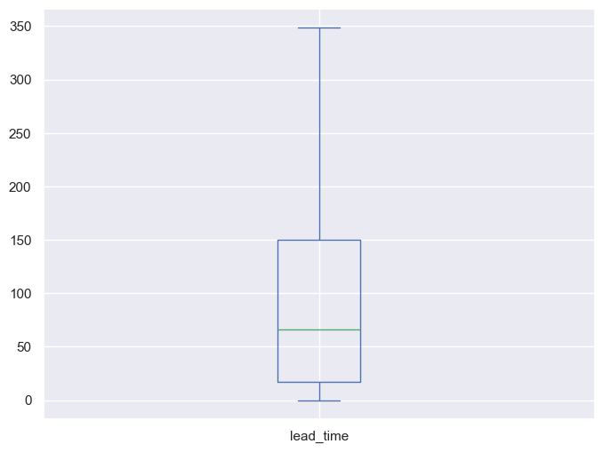

```python
hotel_df = hotel_df.drop(hotel_df[hotel_df['lead_time'] > 349].index )

hotel_df.plot(y=['lead_time'],kind='box',figsize=(8,6))
```

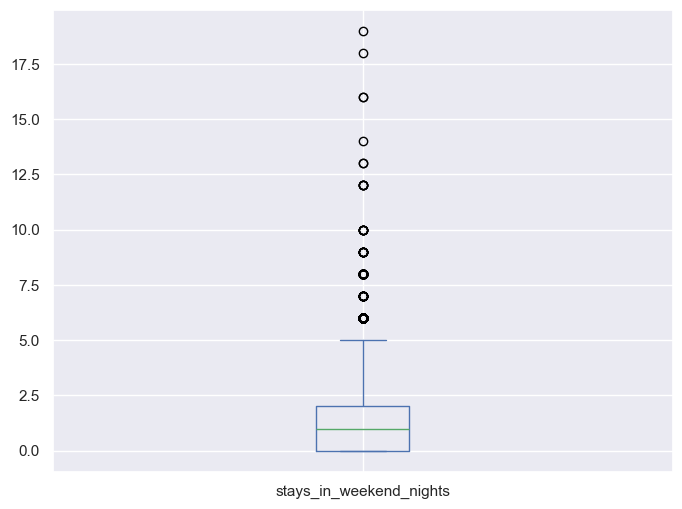

```python
# Plotting box plot for stays_in_week_nights and there are outliers

hotel_df.plot(y=['stays_in_weekend_nights'],kind='box',figsize=(8,6))
```

```python
# finding the outliers using describe method

hotel_df['stays_in_weekend_nights'].describe()
```

```
count    114424.000000
mean          0.942433
std           0.996668
min           0.000000
25%           0.000000
50%           1.000000
75%           2.000000
max          19.000000
Name: stays_in_weekend_nights, dtype: float64
```

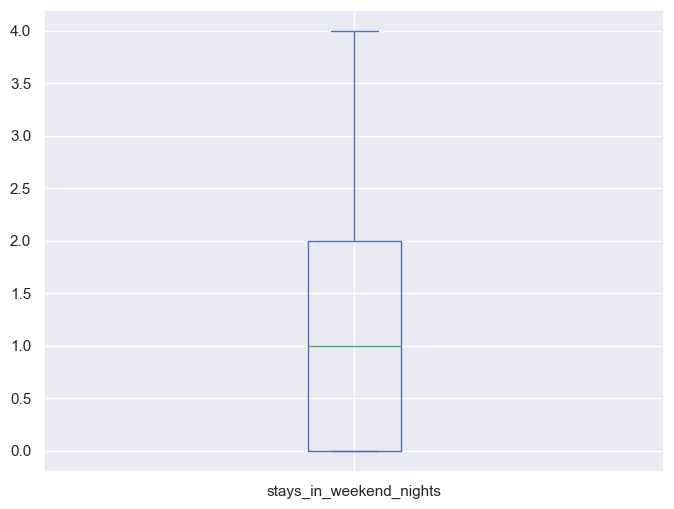

```python
# Dropping outliers of column stays_in_weekend_nights and outliers are where the value is more than 4.

hotel_df = hotel_df.drop(hotel_df[hotel_df['stays_in_weekend_nights'] > 4].index )

hotel_df.plot(y=['stays_in_weekend_nights'],kind='box',figsize=(8,6))
```

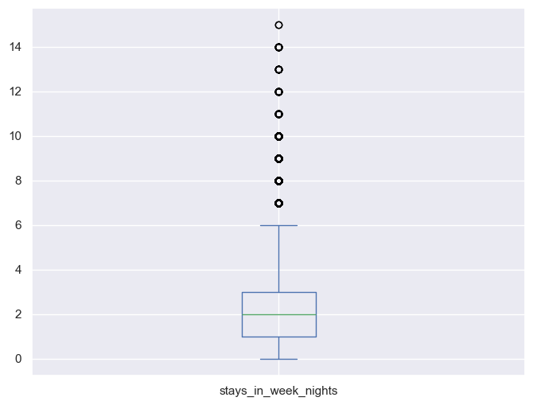

```python
# Plotting box plot for stays_in_week_nights and there are outliers

hotel_df.plot(y=['stays_in_week_nights'],kind='box',figsize=(8,6))
```

```python
# finding the outliers using describe method

hotel_df['stays_in_week_nights'].describe()
```

```
count    114092.000000
mean          2.484793
std           1.729553
min           0.000000
25%           1.000000
50%           2.000000
75%           3.000000
max          15.000000
Name: stays_in_week_nights, dtype: float64
```

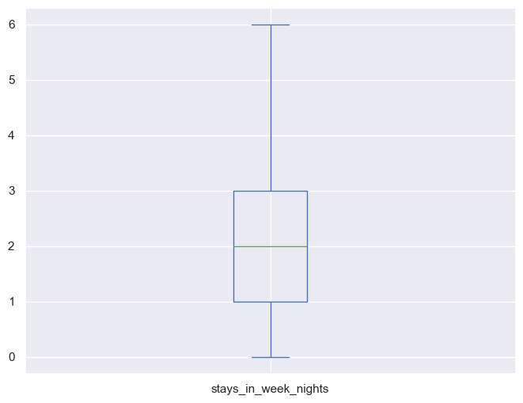

```python
# Dropping outliers of column stays_in_week_nights which is more than 6 as the max is 6

hotel_df = hotel_df.drop(hotel_df[hotel_df['stays_in_week_nights'] > 6].index )

hotel_df.plot(y=['stays_in_week_nights'],kind='box',figsize=(8,6))
```

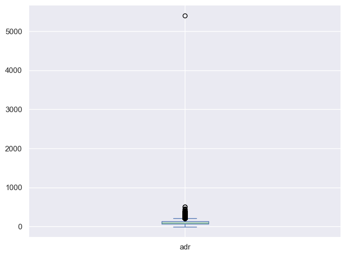

```python
# Plotting box plot for adr and there are outliers

hotel_df.plot(y=['adr'],kind='box',figsize=(8,6))
```

```python
# finding the outliers using describe method

hotel_df['adr'].describe()
```

```
count    111162.000000
mean        103.397404
std          50.349869
min          -6.380000
25%          71.400000
50%          95.000000
75%         127.000000
max        5400.000000
Name: adr, dtype: float64
```

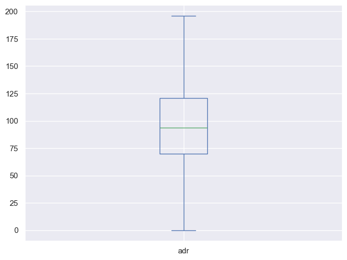

```python
# Dropping outliers of column ADR

hotel_df = hotel_df.drop(hotel_df[(hotel_df['adr'] > 196) | (hotel_df['adr'] < 0)].index )

hotel_df.plot(y=['adr'],kind='box',figsize=(8,6))
```

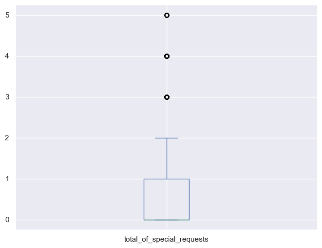

```python
# Plotting box plot for total_of_special_requests and there are outliers

hotel_df.plot(y=['total_of_special_requests'],kind='box',figsize=(8,6))
```

```python
# finding the outliers using describe method

hotel_df['total_of_special_requests'].describe()
```

```
count    105846.000000
mean          0.565756
std           0.786212
min           0.000000
25%           0.000000
50%           0.000000
75%           1.000000
max           5.000000
Name: total_of_special_requests, dtype: float64
```

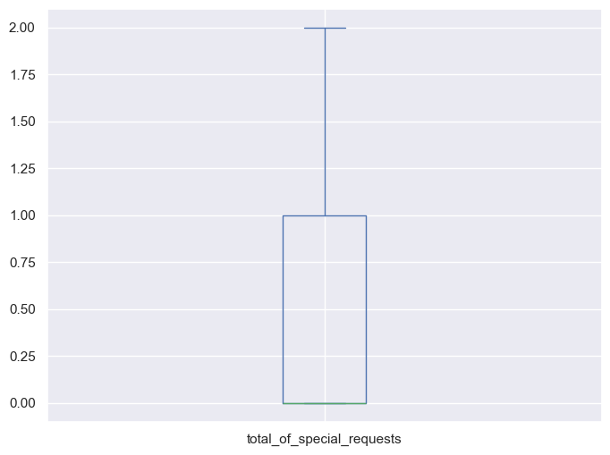

```python
# Dropping outliers of column total_of_special_requests

hotel_df = hotel_df.drop(hotel_df[hotel_df['total_of_special_requests'] > 2].index )

hotel_df.plot(y=['total_of_special_requests'],kind='box',figsize=(8,6))
```

****I have deleted the outliers from the dataset because they can distort statistical analyses and lead to inaccurate model predictions. Outliers may not reflect typical behavior in the data and can significantly impact key metrics like mean and standard deviation. By removing them, I aim to improve the model's performance and enhance its predictive accuracy, ensuring the results better represent the underlying patterns in the data. This step helps create a more robust model that generalizes well to unseen data.****

## 1.3 Column data type conversion (5%)

All necessary columns should be correctly converted to appropriate data types.

****I am converting the `children` column from `floating value` to the integer type using `astype('int64')`. This ensures that the data is in the correct format for any numerical analysis or modeling.****

```python
#covert float type to int

hotel_df['children'] = hotel_df['children'].astype('int64')
hotel_df
```

|  | hotel | is_canceled | lead_time | stays_in_weekend_nights | stays_in_week_nights | adults | children | babies | meal | distribution_channel | ... | previous_cancellations | reserved_room_type | assigned_room_type | booking_changes | deposit_type | days_in_waiting_list | customer_type | adr | required_car_parking_spaces | total_of_special_requests |
| --- | --- | --- | --- | --- | --- | --- | --- | --- | --- | --- | --- | --- | --- | --- | --- | --- | --- | --- | --- | --- | --- |
| 0 | Resort Hotel | 0 | 7 | 0 | 1 | 1 | 0 | 0 | BB | Direct | ... | 0 | A | C | 0 | No Deposit | 0 | Transient | 75.00 | 0 | 0 |
| 1 | Resort Hotel | 0 | 13 | 0 | 1 | 1 | 0 | 0 | BB | Corporate | ... | 0 | A | A | 0 | No Deposit | 0 | Transient | 75.00 | 0 | 0 |
| 2 | Resort Hotel | 0 | 14 | 0 | 2 | 2 | 0 | 0 | BB | TA/TO | ... | 0 | A | A | 0 | No Deposit | 0 | Transient | 98.00 | 0 | 1 |
| 3 | Resort Hotel | 0 | 14 | 0 | 2 | 2 | 0 | 0 | BB | TA/TO | ... | 0 | A | A | 0 | No Deposit | 0 | Transient | 98.00 | 0 | 1 |
| 4 | Resort Hotel | 0 | 0 | 0 | 2 | 2 | 0 | 0 | BB | Direct | ... | 0 | C | C | 0 | No Deposit | 0 | Transient | 107.00 | 0 | 0 |
| ... | ... | ... | ... | ... | ... | ... | ... | ... | ... | ... | ... | ... | ... | ... | ... | ... | ... | ... | ... | ... | ... |
| 118333 | City Hotel | 0 | 188 | 2 | 3 | 2 | 0 | 0 | BB | Direct | ... | 0 | A | A | 0 | No Deposit | 0 | Transient | 99.00 | 0 | 0 |
| 118335 | City Hotel | 0 | 164 | 2 | 4 | 2 | 0 | 0 | BB | TA/TO | ... | 0 | A | A | 0 | No Deposit | 0 | Transient | 87.60 | 0 | 0 |
| 118336 | City Hotel | 0 | 21 | 2 | 5 | 2 | 0 | 0 | BB | TA/TO | ... | 0 | A | A | 0 | No Deposit | 0 | Transient | 96.14 | 0 | 2 |
| 118337 | City Hotel | 0 | 23 | 2 | 5 | 2 | 0 | 0 | BB | TA/TO | ... | 0 | A | A | 0 | No Deposit | 0 | Transient | 96.14 | 0 | 0 |
| 118340 | City Hotel | 0 | 109 | 2 | 5 | 2 | 0 | 0 | BB | TA/TO | ... | 0 | A | A | 0 | No Deposit | 0 | Transient | 104.40 | 0 | 0 |

103422 rows × 21 columns

# 2. Exploratory Data Analysis (25%)

You've also been provided with examples of valuable insights that could be of interest to hotel management, including:

- Calculating cancellation percentages for City and Resort hotels.
- Identifying the most frequently ordered meal types.
- Determining the number of returning guests.
- Discovering the most booked room types.
- Exploring correlations between room types and cancellations.

Visualize these insights using three different types of visualizations covered in the practicals, such as:

- Bar graphs
- Pie charts
- Line charts
- Heatmaps

## 2.1. Calculating cancellation percentages for City and Resort hotels.

```python
# Checking what columns I have left after dropping and cleaning the data

hotel_df.columns
```

```
Index(['hotel', 'is_canceled', 'lead_time', 'stays_in_weekend_nights',
       'stays_in_week_nights', 'adults', 'children', 'babies', 'meal',
       'distribution_channel', 'is_repeated_guest', 'previous_cancellations',
       'reserved_room_type', 'assigned_room_type', 'booking_changes',
       'deposit_type', 'days_in_waiting_list', 'customer_type', 'adr',
       'required_car_parking_spaces', 'total_of_special_requests'],
      dtype='object')
```

- Calculating cancellation percentages for hotels all bookings.

****Now I will look for the unique values in the `is_canceled` column using the `unique` function. This helps me understand the different categories present in the column and the outcome is (array([0, 1], dtype=int64).****

```python
# Now I will look for unique values for column "is_canceled" using unique function.

hotel_df['is_canceled'].unique()
```

```
array([0, 1], dtype=int64)
```

****I am creating a pie chart to visualize the booking cancellations in the `is_canceled` column. The pie chart displays the proportion of canceled versus non-canceled bookings, making it easier to understand the cancellation trends.****

```
colors = ['green', 'red']  # Defines colors for the pie chart
hotel_df['is_canceled'].value_counts().plot(
    title="Booking Cancellation Pie Chart",  # Sets the title of the pie chart
    kind='pie',  # Specifies the type of plot
    autopct='%.1f%%',  # Formats the percentage display
    shadow=True,  # Adds shadow to the pie chart
    colors=colors  # Applies the defined colors
)
```

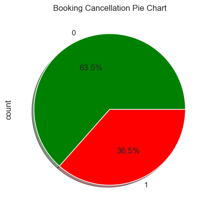

```python
colors = ['green','red']
hotel_df['is_canceled'].value_counts().plot(
    title="Booking Cancellation Pie Chart",
    kind='pie',
    autopct='%.1f%%',
    shadow=True,
    colors=colors
)
```

- Calculating cancellation percentages for City and Resort hotels.

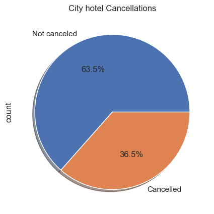

```python
# Filter the dataset for city and resort cancellations

hotel_df_canceled_city = hotel_df.drop(hotel_df[hotel_df['hotel'] == 1].index)  # Drops resort hotels
hotel_df_canceled_resort = hotel_df.drop(hotel_df[hotel_df['hotel'] == 0].index)  # Drops city hotels


# Plot the pie chart
hotel_df_canceled_city.is_canceled.value_counts().plot(kind='pie',
                                                       labels = ["Not canceled" , "Cancelled"],
                                                       title = 'City hotel Cancellations',
                                                       autopct = '%.1f%%',
                                                       shadow=True
                                                       )
```

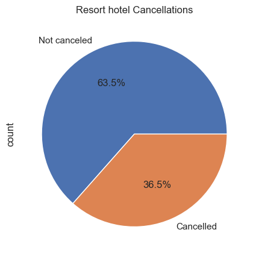

```python
# Doing same this to find out Resort hotel cancellations

hotel_df_canceled_resort.is_canceled.value_counts().plot(kind='pie',
                                                         labels = ["Not canceled" , "Cancelled"],title= 'Resort hotel Cancellations',
                                                         autopct='%.1f%%')
```

## 2.2. Identifying the most frequently ordered meal types.

```python
hotel_df.info()
```

```
<class 'pandas.core.frame.DataFrame'>
Index: 103422 entries, 0 to 118340
Data columns (total 21 columns):
 #   Column                       Non-Null Count   Dtype
---  ------                       --------------   -----
 0   hotel                        103422 non-null  object
 1   is_canceled                  103422 non-null  int64
 2   lead_time                    103422 non-null  int64
 3   stays_in_weekend_nights      103422 non-null  int64
 4   stays_in_week_nights         103422 non-null  int64
 5   adults                       103422 non-null  int64
 6   children                     103422 non-null  int64
 7   babies                       103422 non-null  int64
 8   meal                         103422 non-null  object
 9   distribution_channel         103422 non-null  object
 10  is_repeated_guest            103422 non-null  int64
 11  previous_cancellations       103422 non-null  int64
 12  reserved_room_type           103422 non-null  object
 13  assigned_room_type           103422 non-null  object
 14  booking_changes              103422 non-null  int64
 15  deposit_type                 103422 non-null  object
 16  days_in_waiting_list         103422 non-null  int64
 17  customer_type                103422 non-null  object
 18  adr                          103422 non-null  float64
 19  required_car_parking_spaces  103422 non-null  int64
 20  total_of_special_requests    103422 non-null  int64
dtypes: float64(1), int64(13), object(7)
memory usage: 21.4+ MB
```

****I am examining the unique values in the `meal` column using the `unique()` function. This helps me understand the different meal plans offered in the dataset. The outcome of this operation reveals the following unique meal types:****

indicating the following meal plans:

- BB: Bed and Breakfast
- FB: Full Board (includes all meals)
- HB: Half Board (includes breakfast and one other meal)
- SC: Self-Catering
- Undefined: No specific meal plan is provided

```python
hotel_df.meal.unique() # tried 2 different ways to find unique values
```

```
array(['BB', 'FB', 'HB', 'SC', 'Undefined'], dtype=object)
```

```python
# I am checking the type of meals

hotel_df['meal'].unique() # this shows that there are 5 different type of meals
```

```
array(['BB', 'FB', 'HB', 'SC', 'Undefined'], dtype=object)
```

****In this pie chart it is displaying the most frequent meals been ordered.****

- BB: `78%`
- FB: `0.7%`
- HB: `10.6%`
- SC: `9.8%`
- Undefined: `1.0%`

**** This shows that BB is the one which ordered the most and that is bed and breakfast.

1. **Defining Colors and Explode Parameters:**
   - I define a list of colors to represent each meal category in the pie chart.
   - The `explode` parameter is set to slightly separate the "Undefined" and "FB" slices for better visibility in the pie chart.

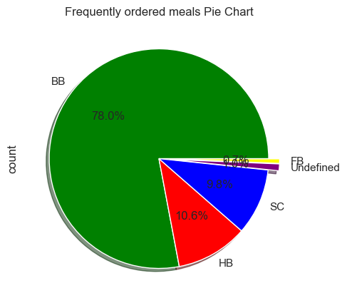

```python
colors = ['green','red','blue','purple','yellow']

# Adding explode to separate "Undefined" and "FB" slightly
explode = (0, 0, 0, 0.1, 0.1)  # Explode only the last two slices

hotel_df['meal'].value_counts().plot(
    title="Frequently ordered meals Pie Chart",
    kind='pie',
    autopct='%.1f%%',
    shadow=True,
    colors=colors,
    explode = explode
)
```

```python
hotel_df['meal'].value_counts()
```

```
meal
BB           80639
HB           10966
SC           10108
Undefined     1030
FB             679
Name: count, dtype: int64
```

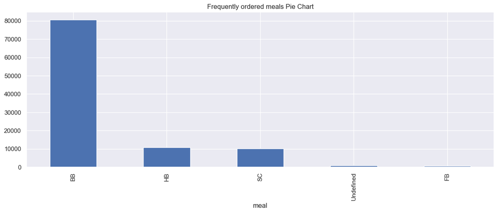

```python
# displaying the quantity of all the meal using the bar plot and I got the info of all meals by using the `value_count()`
hotel_df['meal'].value_counts().plot(
    title="Frequently ordered meals Pie Chart",
    kind='bar'
)
```

## 2.3. Determining the number of returning guests.

```python
hotel_df.columns
```

```
Index(['hotel', 'is_canceled', 'lead_time', 'stays_in_weekend_nights',
       'stays_in_week_nights', 'adults', 'children', 'babies', 'meal',
       'distribution_channel', 'is_repeated_guest', 'previous_cancellations',
       'reserved_room_type', 'assigned_room_type', 'booking_changes',
       'deposit_type', 'days_in_waiting_list', 'customer_type', 'adr',
       'required_car_parking_spaces', 'total_of_special_requests'],
      dtype='object')
```

```python
# Finding the repeated guest using sum() function on column is_repeated_guest

# Directly compute the number of returning guests

print(f"Total number of returning guests are: {hotel_df['is_repeated_guest'].sum()}")
```

```
Total number of returning guests are: 3218
```

```python
# checking on what index the repeated guests are

hotel_df['is_repeated_guest'].index
```

```
Index([     0,      1,      2,      3,      4,      5,      6,      7,      8,
            9,
       ...
       118327, 118329, 118330, 118331, 118332, 118333, 118335, 118336, 118337,
       118340],
      dtype='int64', length=103422)
```

```python
hotel_df['is_repeated_guest'].unique()
```

```
array([0, 1], dtype=int64)
```

****I am counting the values for the `is_repeated_guest` column to understand the distribution of repeated versus non-repeated guests. This analysis helps in assessing guest loyalty and behavior.****

1. **Counting Guest Values:**
- Not Repeated Guest: `96.9%`
- Repeated Guest: `3.1%`

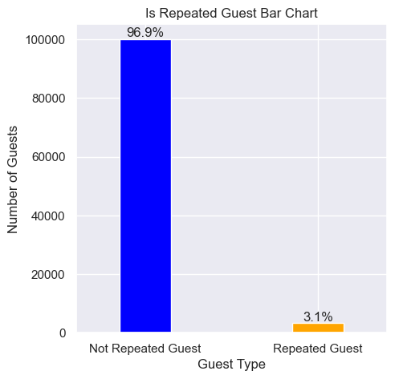

```python
# Count the values for 'is_repeated_guest'
guest_counts = hotel_df['is_repeated_guest'].value_counts()

# Plot the bar chart
ax = guest_counts.plot(
    kind='bar',
    figsize=[5, 5],
    width=0.3,
    color=['blue', 'orange'],
    title="Is Repeated Guest Bar Chart"
)

# Custom labels for the x-axis
ax.set_xticklabels(['Not Repeated Guest', 'Repeated Guest'], rotation=0)

# Calculate total count for percentage calculation
total = guest_counts.sum()

# Add percentage annotations on each bar
for p in ax.patches:
    percentage = f'{100 * p.get_height() / total:.1f}%'
    ax.annotate(percentage,
                (p.get_x() + p.get_width() / 2, p.get_height()),   # Position
                ha='center', va='bottom')  # Centering the text

# Set labels
plt.xlabel('Guest Type')
plt.ylabel('Number of Guests')

# Show the plot
plt.show()
```

[figure not shown]

```python
# simply pie chart for Repeated and Non repeated guests
explode = (0.1, 0.1)

hotel_df['is_repeated_guest'].value_counts().plot(
    title="Repeated Customer Pie Chart",
    labels=["Repeated Guest", "Normal Guest"],
    autopct='%.1f%%',
    kind='pie',
    shadow=True,
    explode = explode
)
```

## 2.4. Discovering the most booked room types.

```python
# first I checked all the type of rooms and their values and it shows that Room type A is the which was Booked for customers.

hotel_df.reserved_room_type.value_counts()
```

```
reserved_room_type
A    77693
D    16410
E     4757
F     1742
G     1104
B      836
C      546
H      329
L        5
Name: count, dtype: int64
```

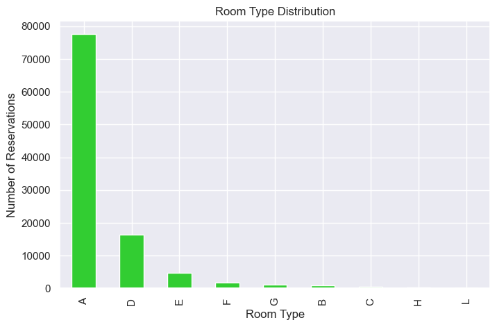

```python
# Count the values for 'reserved_room_type'
room_counts = hotel_df['reserved_room_type'].value_counts()

# Plot the bar chart
ax = room_counts.plot(
    kind='bar',
    figsize=[8, 5],  # Adjust size as needed
    color='limegreen',  # You can choose any color
    title="Room Type Distribution"
)
# Set labels
plt.xlabel('Room Type')
plt.ylabel('Number of Reservations')

# Display the chart
plt.show()
```

## 2.5. Exploring correlations between room types and cancellations.

****In this step, I am converting the `reserved_room_type` and `is_canceled` columns into categorical codes. This process allows for better handling of these variables in subsequent analyses, especially when modeling.****

1. **Converting Columns to Categorical Codes:**
   - I convert the `reserved_room_type` column to a categorical type and then to numerical codes using the `astype('category').cat.codes` method. This replaces the string values with integer codes that can be used for analysis and modeling.

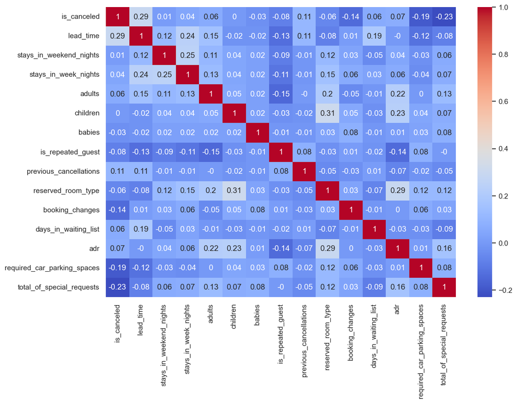

```python
hotel_df['reserved_room_type'] = hotel_df['reserved_room_type'].astype('category').cat.codes
hotel_df['is_canceled'] = hotel_df['is_canceled'].astype('category').cat.codes

# hotel_df.corr(numeric_only=True)

corr = hotel_df.corr(numeric_only=True).round(2)
sb.set (rc = {'figure.figsize': (12, 8)})
sb.heatmap(corr, cmap = "coolwarm", annot=True)
```

```python
hotel_df.info()
```

```
<class 'pandas.core.frame.DataFrame'>
Index: 103422 entries, 0 to 118340
Data columns (total 21 columns):
 #   Column                       Non-Null Count   Dtype
---  ------                       --------------   -----
 0   hotel                        103422 non-null  object
 1   is_canceled                  103422 non-null  int8
 2   lead_time                    103422 non-null  int64
 3   stays_in_weekend_nights      103422 non-null  int64
 4   stays_in_week_nights         103422 non-null  int64
 5   adults                       103422 non-null  int64
 6   children                     103422 non-null  int64
 7   babies                       103422 non-null  int64
 8   meal                         103422 non-null  object
 9   distribution_channel         103422 non-null  object
 10  is_repeated_guest            103422 non-null  int64
 11  previous_cancellations       103422 non-null  int64
 12  reserved_room_type           103422 non-null  int8
 13  assigned_room_type           103422 non-null  object
 14  booking_changes              103422 non-null  int64
 15  deposit_type                 103422 non-null  object
 16  days_in_waiting_list         103422 non-null  int64
 17  customer_type                103422 non-null  object
 18  adr                          103422 non-null  float64
 19  required_car_parking_spaces  103422 non-null  int64
 20  total_of_special_requests    103422 non-null  int64
dtypes: float64(1), int64(12), int8(2), object(6)
memory usage: 20.0+ MB
```

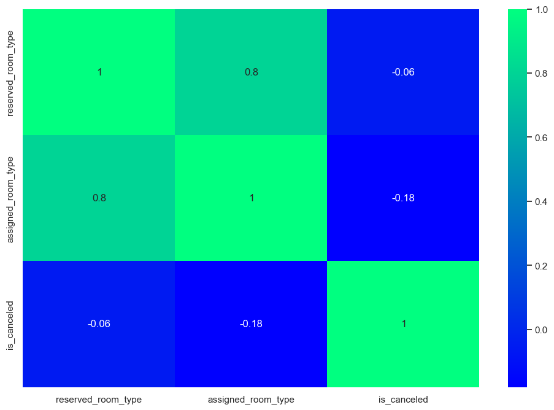

```python
hotel_df['reserved_room_type'] = hotel_df['reserved_room_type'].astype('category').cat.codes
hotel_df['assigned_room_type'] = hotel_df['assigned_room_type'].astype('category').cat.codes

data = hotel_df[['reserved_room_type','assigned_room_type','is_canceled']]

corr = data.corr(numeric_only=True).round(2)
sb.heatmap(corr, cmap = "winter", annot=True)
```

# 3. Feature Engineering (20%)

Apply various feature engineering techniques, covered in the lectures and practicals.

Hint:

- Binning
- Encoding
- Scaling
- Feature selection

## 3.1. Binning

***Distribution Plot of ADR (Average Daily Rate)***

- sb.displot: Used to create a histogram for the adr column to visualize how often different daily rates occur.
- data=hotel_df: Specifies the DataFrame with the data.
- x='adr': Plots the Average Daily Rate values on the x-axis.
- bins=30: Groups the data into 30 intervals (bins) for a more detailed view of ADR distribution.

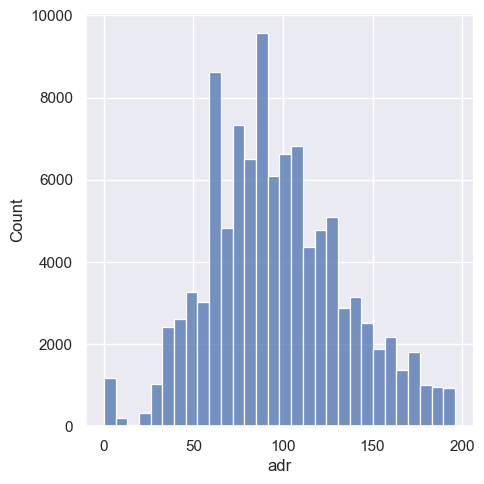

```python
sb.displot(data=hotel_df, x='adr',bins = 30)
```

## 3.2. Encoding

```python
#Getting information of the data frame for encoding
hotel_df.info()
```

```
<class 'pandas.core.frame.DataFrame'>
Index: 103422 entries, 0 to 118340
Data columns (total 21 columns):
 #   Column                       Non-Null Count   Dtype
---  ------                       --------------   -----
 0   hotel                        103422 non-null  object
 1   is_canceled                  103422 non-null  int8
 2   lead_time                    103422 non-null  int64
 3   stays_in_weekend_nights      103422 non-null  int64
 4   stays_in_week_nights         103422 non-null  int64
 5   adults                       103422 non-null  int64
 6   children                     103422 non-null  int64
 7   babies                       103422 non-null  int64
 8   meal                         103422 non-null  object
 9   distribution_channel         103422 non-null  object
 10  is_repeated_guest            103422 non-null  int64
 11  previous_cancellations       103422 non-null  int64
 12  reserved_room_type           103422 non-null  int8
 13  assigned_room_type           103422 non-null  int8
 14  booking_changes              103422 non-null  int64
 15  deposit_type                 103422 non-null  object
 16  days_in_waiting_list         103422 non-null  int64
 17  customer_type                103422 non-null  object
 18  adr                          103422 non-null  float64
 19  required_car_parking_spaces  103422 non-null  int64
 20  total_of_special_requests    103422 non-null  int64
dtypes: float64(1), int64(12), int8(3), object(5)
memory usage: 19.3+ MB
```

```python
# simply using cat.codes to convert the hotels column values to integers as in encoding categorical values wont work

hotel_df['hotel'] = hotel_df['hotel'].astype('category').cat.codes
```

```python
# resetting the data frame to clear all the empty rows

hotel_df.reset_index(drop=True, inplace =True)
```

****One-Hot Encoding of the 'meal' Column in Hotel Booking Data****

In this section, we will demonstrate how to apply one-hot encoding to the `meal` column of our hotel booking dataset. This process converts categorical data into a format that can be provided to machine learning algorithms.

```python
# Initialize OneHotEncoder from sklearn

ohe = OneHotEncoder(sparse_output=False)

# drop='first' to avoid the dummy variable trap (optional)

# Apply OneHotEncoder to the 'Segment' column

Ohe_coded = ohe.fit_transform(hotel_df[['meal']])

# Convert the result into a DataFrame with proper column names

one_hot_df = pd.DataFrame(Ohe_coded,columns=ohe.get_feature_names_out(['meal']))

# Drop the original 'Segment' column

data_of_bookings = hotel_df.drop('meal', axis=1)

# Join the new one-hot encoded df back to the original

data_of_bookings = data_of_bookings.join(one_hot_df)

data_of_bookings
```

|  | hotel | is_canceled | lead_time | stays_in_weekend_nights | stays_in_week_nights | adults | children | babies | distribution_channel | is_repeated_guest | ... | days_in_waiting_list | customer_type | adr | required_car_parking_spaces | total_of_special_requests | meal_BB | meal_FB | meal_HB | meal_SC | meal_Undefined |
| --- | --- | --- | --- | --- | --- | --- | --- | --- | --- | --- | --- | --- | --- | --- | --- | --- | --- | --- | --- | --- | --- |
| 0 | 1 | 0 | 7 | 0 | 1 | 1 | 0 | 0 | Direct | 0 | ... | 0 | Transient | 75.00 | 0 | 0 | 1.0 | 0.0 | 0.0 | 0.0 | 0.0 |
| 1 | 1 | 0 | 13 | 0 | 1 | 1 | 0 | 0 | Corporate | 0 | ... | 0 | Transient | 75.00 | 0 | 0 | 1.0 | 0.0 | 0.0 | 0.0 | 0.0 |
| 2 | 1 | 0 | 14 | 0 | 2 | 2 | 0 | 0 | TA/TO | 0 | ... | 0 | Transient | 98.00 | 0 | 1 | 1.0 | 0.0 | 0.0 | 0.0 | 0.0 |
| 3 | 1 | 0 | 14 | 0 | 2 | 2 | 0 | 0 | TA/TO | 0 | ... | 0 | Transient | 98.00 | 0 | 1 | 1.0 | 0.0 | 0.0 | 0.0 | 0.0 |
| 4 | 1 | 0 | 0 | 0 | 2 | 2 | 0 | 0 | Direct | 0 | ... | 0 | Transient | 107.00 | 0 | 0 | 1.0 | 0.0 | 0.0 | 0.0 | 0.0 |
| ... | ... | ... | ... | ... | ... | ... | ... | ... | ... | ... | ... | ... | ... | ... | ... | ... | ... | ... | ... | ... | ... |
| 103417 | 0 | 0 | 188 | 2 | 3 | 2 | 0 | 0 | Direct | 0 | ... | 0 | Transient | 99.00 | 0 | 0 | 1.0 | 0.0 | 0.0 | 0.0 | 0.0 |
| 103418 | 0 | 0 | 164 | 2 | 4 | 2 | 0 | 0 | TA/TO | 0 | ... | 0 | Transient | 87.60 | 0 | 0 | 1.0 | 0.0 | 0.0 | 0.0 | 0.0 |
| 103419 | 0 | 0 | 21 | 2 | 5 | 2 | 0 | 0 | TA/TO | 0 | ... | 0 | Transient | 96.14 | 0 | 2 | 1.0 | 0.0 | 0.0 | 0.0 | 0.0 |
| 103420 | 0 | 0 | 23 | 2 | 5 | 2 | 0 | 0 | TA/TO | 0 | ... | 0 | Transient | 96.14 | 0 | 0 | 1.0 | 0.0 | 0.0 | 0.0 | 0.0 |
| 103421 | 0 | 0 | 109 | 2 | 5 | 2 | 0 | 0 | TA/TO | 0 | ... | 0 | Transient | 104.40 | 0 | 0 | 1.0 | 0.0 | 0.0 | 0.0 | 0.0 |

103422 rows × 25 columns

```python
data_of_bookings.info()
```

```
<class 'pandas.core.frame.DataFrame'>
RangeIndex: 103422 entries, 0 to 103421
Data columns (total 25 columns):
 #   Column                       Non-Null Count   Dtype
---  ------                       --------------   -----
 0   hotel                        103422 non-null  int8
 1   is_canceled                  103422 non-null  int8
 2   lead_time                    103422 non-null  int64
 3   stays_in_weekend_nights      103422 non-null  int64
 4   stays_in_week_nights         103422 non-null  int64
 5   adults                       103422 non-null  int64
 6   children                     103422 non-null  int64
 7   babies                       103422 non-null  int64
 8   distribution_channel         103422 non-null  object
 9   is_repeated_guest            103422 non-null  int64
```

[output cut: 17 more lines]

**Doing same thing for `distribution_channel`**

```python
# Apply OneHotEncoder to the 'distribution_channel' column
ohe_coded = ohe.fit_transform(data_of_bookings[['distribution_channel']])

# Convert the result into a DataFrame with proper column names
one_hot_df = pd.DataFrame(ohe_coded,columns=ohe.get_feature_names_out(['distribution_channel']))

# Drop the original 'distribution_channel' column
data_of_bookings = data_of_bookings.drop('distribution_channel', axis=1)

# Join the new one-hot encoded df back to the original
data_of_bookings = data_of_bookings.join(one_hot_df)

data_of_bookings
```

|  | hotel | is_canceled | lead_time | stays_in_weekend_nights | stays_in_week_nights | adults | children | babies | is_repeated_guest | previous_cancellations | ... | meal_BB | meal_FB | meal_HB | meal_SC | meal_Undefined | distribution_channel_Corporate | distribution_channel_Direct | distribution_channel_GDS | distribution_channel_TA/TO | distribution_channel_Undefined |
| --- | --- | --- | --- | --- | --- | --- | --- | --- | --- | --- | --- | --- | --- | --- | --- | --- | --- | --- | --- | --- | --- |
| 0 | 1 | 0 | 7 | 0 | 1 | 1 | 0 | 0 | 0 | 0 | ... | 1.0 | 0.0 | 0.0 | 0.0 | 0.0 | 0.0 | 1.0 | 0.0 | 0.0 | 0.0 |
| 1 | 1 | 0 | 13 | 0 | 1 | 1 | 0 | 0 | 0 | 0 | ... | 1.0 | 0.0 | 0.0 | 0.0 | 0.0 | 1.0 | 0.0 | 0.0 | 0.0 | 0.0 |
| 2 | 1 | 0 | 14 | 0 | 2 | 2 | 0 | 0 | 0 | 0 | ... | 1.0 | 0.0 | 0.0 | 0.0 | 0.0 | 0.0 | 0.0 | 0.0 | 1.0 | 0.0 |
| 3 | 1 | 0 | 14 | 0 | 2 | 2 | 0 | 0 | 0 | 0 | ... | 1.0 | 0.0 | 0.0 | 0.0 | 0.0 | 0.0 | 0.0 | 0.0 | 1.0 | 0.0 |
| 4 | 1 | 0 | 0 | 0 | 2 | 2 | 0 | 0 | 0 | 0 | ... | 1.0 | 0.0 | 0.0 | 0.0 | 0.0 | 0.0 | 1.0 | 0.0 | 0.0 | 0.0 |
| ... | ... | ... | ... | ... | ... | ... | ... | ... | ... | ... | ... | ... | ... | ... | ... | ... | ... | ... | ... | ... | ... |
| 103417 | 0 | 0 | 188 | 2 | 3 | 2 | 0 | 0 | 0 | 0 | ... | 1.0 | 0.0 | 0.0 | 0.0 | 0.0 | 0.0 | 1.0 | 0.0 | 0.0 | 0.0 |
| 103418 | 0 | 0 | 164 | 2 | 4 | 2 | 0 | 0 | 0 | 0 | ... | 1.0 | 0.0 | 0.0 | 0.0 | 0.0 | 0.0 | 0.0 | 0.0 | 1.0 | 0.0 |
| 103419 | 0 | 0 | 21 | 2 | 5 | 2 | 0 | 0 | 0 | 0 | ... | 1.0 | 0.0 | 0.0 | 0.0 | 0.0 | 0.0 | 0.0 | 0.0 | 1.0 | 0.0 |
| 103420 | 0 | 0 | 23 | 2 | 5 | 2 | 0 | 0 | 0 | 0 | ... | 1.0 | 0.0 | 0.0 | 0.0 | 0.0 | 0.0 | 0.0 | 0.0 | 1.0 | 0.0 |
| 103421 | 0 | 0 | 109 | 2 | 5 | 2 | 0 | 0 | 0 | 0 | ... | 1.0 | 0.0 | 0.0 | 0.0 | 0.0 | 0.0 | 0.0 | 0.0 | 1.0 | 0.0 |

103422 rows × 29 columns

```python
data_of_bookings.deposit_type.value_counts()
```

```
deposit_type
No Deposit    91086
Non Refund    12186
Refundable      150
Name: count, dtype: int64
```

**Given that the column has only a few distinct values (No Deposit, Non-Refund, Refundable), we can handle the replacements more efficiently through manual adjustments.**

deposit_type

- No Deposit:`91086` using `.replace` this will be `0`
- Non Refund:`12186` using `.replace` this will be `2`
- Refundable:`150` using `.replace` this will be `1`

```python
data_of_deposit = data_of_bookings.deposit_type.unique()



data_of_bookings['deposit_type'] = data_of_bookings['deposit_type'].replace({data_of_deposit[0]: 0, data_of_deposit[1]: 1, data_of_deposit[2]: 2})

data_of_bookings.deposit_type.value_counts()
```

```
deposit_type
0    91086
2    12186
1      150
Name: count, dtype: int64
```

```python
# below in the outcome it is showing that there are different types of customers therefore we will do encoding on them
data_of_bookings.customer_type.value_counts()
```

```
customer_type
Transient          77246
Transient-Party    22546
Contract            3126
Group                504
Name: count, dtype: int64
```

```python
# Categorical Data encoding using scikitlearn one hot encoding:

# Apply OneHotEncoder to the 'customer_type' column
ohe_coded = ohe.fit_transform(data_of_bookings[['customer_type']])

# Convert the result into a DataFrame with proper column names
one_hot_df = pd.DataFrame(ohe_coded,columns=ohe.get_feature_names_out(['customer_type']))

# Drop the original 'customer_type' column
data_of_bookings = data_of_bookings.drop('customer_type', axis=1)

# Join the new one-hot encoded df back to the original
data_of_bookings = data_of_bookings.join(one_hot_df)

data_of_bookings
```

|  | hotel | is_canceled | lead_time | stays_in_weekend_nights | stays_in_week_nights | adults | children | babies | is_repeated_guest | previous_cancellations | ... | meal_Undefined | distribution_channel_Corporate | distribution_channel_Direct | distribution_channel_GDS | distribution_channel_TA/TO | distribution_channel_Undefined | customer_type_Contract | customer_type_Group | customer_type_Transient | customer_type_Transient-Party |
| --- | --- | --- | --- | --- | --- | --- | --- | --- | --- | --- | --- | --- | --- | --- | --- | --- | --- | --- | --- | --- | --- |
| 0 | 1 | 0 | 7 | 0 | 1 | 1 | 0 | 0 | 0 | 0 | ... | 0.0 | 0.0 | 1.0 | 0.0 | 0.0 | 0.0 | 0.0 | 0.0 | 1.0 | 0.0 |
| 1 | 1 | 0 | 13 | 0 | 1 | 1 | 0 | 0 | 0 | 0 | ... | 0.0 | 1.0 | 0.0 | 0.0 | 0.0 | 0.0 | 0.0 | 0.0 | 1.0 | 0.0 |
| 2 | 1 | 0 | 14 | 0 | 2 | 2 | 0 | 0 | 0 | 0 | ... | 0.0 | 0.0 | 0.0 | 0.0 | 1.0 | 0.0 | 0.0 | 0.0 | 1.0 | 0.0 |
| 3 | 1 | 0 | 14 | 0 | 2 | 2 | 0 | 0 | 0 | 0 | ... | 0.0 | 0.0 | 0.0 | 0.0 | 1.0 | 0.0 | 0.0 | 0.0 | 1.0 | 0.0 |
| 4 | 1 | 0 | 0 | 0 | 2 | 2 | 0 | 0 | 0 | 0 | ... | 0.0 | 0.0 | 1.0 | 0.0 | 0.0 | 0.0 | 0.0 | 0.0 | 1.0 | 0.0 |
| ... | ... | ... | ... | ... | ... | ... | ... | ... | ... | ... | ... | ... | ... | ... | ... | ... | ... | ... | ... | ... | ... |
| 103417 | 0 | 0 | 188 | 2 | 3 | 2 | 0 | 0 | 0 | 0 | ... | 0.0 | 0.0 | 1.0 | 0.0 | 0.0 | 0.0 | 0.0 | 0.0 | 1.0 | 0.0 |
| 103418 | 0 | 0 | 164 | 2 | 4 | 2 | 0 | 0 | 0 | 0 | ... | 0.0 | 0.0 | 0.0 | 0.0 | 1.0 | 0.0 | 0.0 | 0.0 | 1.0 | 0.0 |
| 103419 | 0 | 0 | 21 | 2 | 5 | 2 | 0 | 0 | 0 | 0 | ... | 0.0 | 0.0 | 0.0 | 0.0 | 1.0 | 0.0 | 0.0 | 0.0 | 1.0 | 0.0 |
| 103420 | 0 | 0 | 23 | 2 | 5 | 2 | 0 | 0 | 0 | 0 | ... | 0.0 | 0.0 | 0.0 | 0.0 | 1.0 | 0.0 | 0.0 | 0.0 | 1.0 | 0.0 |
| 103421 | 0 | 0 | 109 | 2 | 5 | 2 | 0 | 0 | 0 | 0 | ... | 0.0 | 0.0 | 0.0 | 0.0 | 1.0 | 0.0 | 0.0 | 0.0 | 1.0 | 0.0 |

103422 rows × 32 columns

****In the table above it shows that it encoded all the customers types and separated them in different columns.****